# Part II - (Prosper Loan Data Analysis)

## by (Garba Hassan Usman)

## Investigation Overview

> In this investigation, I wanted to look at the factors that affect a loan's outcome status, What affects the borrower’s APR or interest rate, and to see if there are differences between loans depending on how large the original loan amount was?

> Through the visualizations I observed the following:

> The BorrowerRate rises for loans with longer terms at every level of ProsperRating. Given that loans with shorter terms typically have higher interest rates, I would anticipate the opposite. This is a little surprising because it was not at all obvious in the bivariate analysis.

> According to the visualization, the borrower's APR has a wide range of values depending on the size of the total loan amount, but the range of APR diminishes as the loan amount rises. Therefore, there is a bad correlation between the borrower's APR and the overall loan amount.

## Dataset Overview

> This data set contains 113,937 loans with 81 variables on each loan, including loan amount, borrower rate (or interest rate), current loan status, borrower income, and many others. Some of these variables are numerical while some are categorical.

### What connection exists between the original loan amount and the borrower APR?

> The borrower's APR has a wide range of values depending on the size of the total loan amount, but the range of APR diminishes as the loan amount rises. Therefore, there is a bad correlation between the borrower's APR and the overall loan amount.

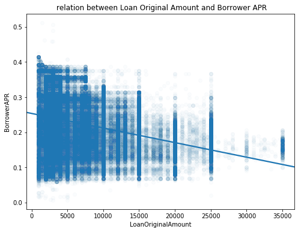

### How are the three category traits related to one another?

> The BorrowerRate rises for loans with longer terms at every level of ProsperRating. Given that loans with shorter terms typically have higher interest rates, I would anticipate the opposite. This is a little surprising because it was not at all obvious in the bivariate analysis.

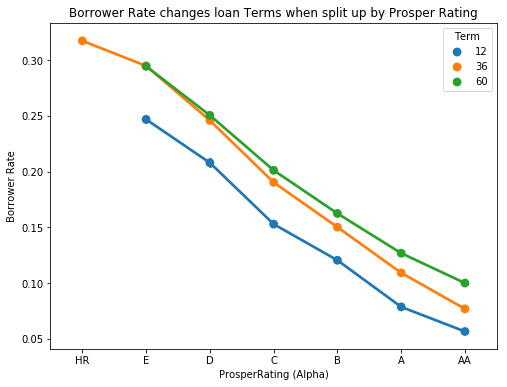

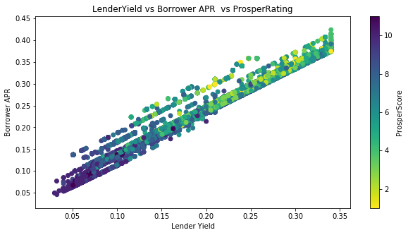